# contr.equal_prior

2024-03-04

I have some questions regarding the contr.equalprior function.

First, I am setting up the brms models. I am attaching an .rds file for the models, such that you don’t need to run them again.

```r
library(emmeans)
library(easystats)
library(brms)
library(tidyverse)
library(here)
library(see)
```

```r
# set-up:
project_seed = 2049
set.seed(project_seed)

# Make df, with 12 subjects, with:
# Group (between subj factor): levels "fam" and "unfam"
# TestSpeaker (within): levels 1,2,3
# sleepState (between): levels awake, activesleep, quietsleep
# MMR: dependent variable
df = structure(list(Subj = structure(c(1L, 1L, 1L, 2L, 2L, 2L, 3L,
                                       3L, 3L, 4L, 4L, 4L, 5L, 5L, 5L, 6L, 6L, 6L, 7L, 7L, 7L, 8L, 8L,
                                       8L, 9L, 9L, 9L, 10L, 10L, 10L, 11L, 11L, 11L, 12L, 12L, 12L),
                                     levels = c("Subj01","Subj02", "Subj03", "Subj04", "Subj05", "Subj06",
                                                "Subj07", "Subj08","Subj09", "Subj10", "Subj11", "Subj12"),
                                     class = "factor"),
                    Group = structure(c(1L, 1L, 1L, 1L, 1L, 1L, 1L, 1L, 1L, 1L, 1L, 1L, 1L, 1L, 1L, 1L, 1L,
                                        1L, 2L, 2L, 2L, 2L, 2L, 2L, 2L, 2L, 2L, 2L, 2L, 2L, 2L, 2L, 2L,
                                        2L, 2L, 2L), levels = c("fam", "unfam"), class = "factor"),
                    TestSpeaker = structure(c(1L, 2L, 3L, 1L, 2L, 3L, 1L, 2L, 3L, 1L, 2L, 3L, 1L, 2L, 3L, 1L, 2L,
                                              3L, 1L, 2L, 3L, 1L, 2L, 3L, 1L, 2L, 3L, 1L, 2L, 3L, 1L, 2L, 3L,
                                              1L, 2L, 3L), levels = c("1", "2", "3"), class = "factor"),
                    MMR = c(38.3193739833394,-26.3345733319488, -36.5391489690257, 17.6727210461579, 13.0723969801114,
                            -4.24116674572545, 21.2481968372323, 11.4709975141478, 1.82856457361663,
                            43.7294164718069, 20.3131479540544, 0.785675781481198, -2.15902787287105,
                            -25.4903371611785, 61.873025266565, 9.06733331354276, -18.7574284113092,
                            6.33216574768327, -34.9097027199614, -3.96327639212982, 15.9747552016853,
                            -38.801070417319, -6.46518128748102, -22.630432474398, 21.9291933267653,
                            24.4946719999554, -31.2847387815119, -8.04032285881707, 14.2321054924562,
                            8.80183458992482, 18.9550435474235, 33.2621031208136, -11.4198082197363,
                            -14.7150081652997, 29.2510483128696, -31.1494998323233),
                    sleepState = structure(c(2L,2L, 2L, 3L, 3L, 3L, 2L, 2L, 2L, 2L, 2L, 2L, 3L, 3L, 3L, 1L, 1L,
                                             1L, 1L, 1L, 1L, 1L, 1L, 1L, 3L, 3L, 3L, 1L, 1L, 1L, 2L, 2L, 2L,
                                             1L, 1L, 1L), levels = c("awake", "activesleep", "quietsleep"), class = "factor")),
               row.names = c(NA,-36L), class = c("tbl_df", "tbl", "data.frame"))

# ### MODEL 1: With  contr.equalprior set globally
# options(contrasts = c("contr.equalprior", "contr.poly"))
# # Same as:
# # contrasts(df$TestSpeaker) <- contr.equalprior
# # contrasts(df$Group) <- contr.equalprior
# # contrasts(df$sleepState) <- contr.equalprior
#
# m1 = brm(MMR ~ 1 + TestSpeaker * Group +
#         sleepState * TestSpeaker +
#         (1 + TestSpeaker * Group | Subj),
#       data = df,
#       family = gaussian(),
#       prior = c(set_prior("normal(5.97, 23.34)",
#                           class = "Intercept"),
#                 set_prior("normal(0, 23.34)",
#                           class = "b"),
#                 set_prior("normal(0, 23.34)",
#                           class = "sigma")),
#       init = "random",
#       control = list(
#         adapt_delta = .99,
#         max_treedepth = 15
#       ),
#       chains = 4,
#       iter = 4000,
#       warmup = 2000,
#       thin = 1,
#       algorithm = "sampling",
#       cores = 4,
#       seed = project_seed,
#       save_pars = save_pars(all = TRUE),
#       file = here("data", "model_output", "m1.rds")
# )
#
# ### MODEL 2: With  contr.equalprior_pairs set globally
#
# options(contrasts = c("contr.equalprior_pairs", "contr.poly"))
# # Same as:
# # contrasts(df$TestSpeaker) <- contr.equalprior_pairs
# # contrasts(df$Group) <- contr.equalprior_pairs
# # contrasts(df$sleepState) <- contr.equalprior_pairs
#
# m2 = brm(MMR ~ 1 + TestSpeaker * Group +
#         sleepState * TestSpeaker +
#         (1 + TestSpeaker * Group | Subj),
#       data = df,
#       family = gaussian(),
#       prior = c(set_prior("normal(5.97, 23.34)",
#                           class = "Intercept"),
#                 set_prior("normal(0, 23.34)",
#                           class = "b"),
#                 set_prior("normal(0, 23.34)",
#                           class = "sigma")),
#       init = "random",
#       control = list(
#         adapt_delta = .99,
#         max_treedepth = 15
#       ),
#       chains = 4,
#       iter = 4000,
#       warmup = 2000,
#       thin = 1,
#       algorithm = "sampling",
#       cores = 4,
#       seed = project_seed,
#       save_pars = save_pars(all = TRUE),
#       file = here("data", "model_output", "m2.rds")
#   )

#import the models from file
# m1 <- readRDS(here("m1.rds"))
# m2 <- readRDS(here("m2.rds"))
m1 <- readRDS(here("data", "model_output","m1.rds"))
m2 <- readRDS(here("data", "model_output","m2.rds"))
```

### Question 1

First, I have a question about the difference between contr.equalprior and contr.equalprior_pairs.

The contrast matrices are different:

```r
contrasts(df$TestSpeaker) <- contr.equalprior_pairs
contrasts(df$TestSpeaker)
```

```
##   [,1]       [,2]
## 1  0.0  0.5773503
## 2 -0.5 -0.2886751
## 3  0.5 -0.2886751
```

```r
contrasts(df$TestSpeaker) <- contr.equalprior
contrasts(df$TestSpeaker)
```

```
##         [,1]       [,2]
## 1  0.0000000  0.8164966
## 2 -0.7071068 -0.4082483
## 3  0.7071068 -0.4082483
```

Since the contrast matrices are different, the outcomes for the priors are of course different. I understand that since I am mostly comparing pairs, I should probably use contr.equalprior_pairs. However, contr.equalprior also seems to give me equal priors (also for my other comparisons below), just with different values:

```r
m_prior <- unupdate(m1, verbose=FALSE) # sample priors from model
m_prior_pairwise <-
  m_prior %>%
  emmeans(~ TestSpeaker)  %>%
  pairs()
```

```
## NOTE: Results may be misleading due to involvement in interactions
```

```r
point_estimate(m_prior_pairwise, centr = "mean", disp = TRUE)
```

```
## Point Estimate
##
## Parameter                   | Mean |    SD
## ------------------------------------------
## TestSpeaker1 - TestSpeaker2 | 0.21 | 32.93
## TestSpeaker1 - TestSpeaker3 | 0.39 | 33.40
## TestSpeaker2 - TestSpeaker3 | 0.18 | 32.72
```

```r
m_prior <- unupdate(m2, verbose=FALSE) # sample priors from model
m_prior_pairwise <-
  m_prior %>%
  emmeans(~ TestSpeaker)  %>%
  pairs()
```

```
## NOTE: Results may be misleading due to involvement in interactions
```

```r
point_estimate(m_prior_pairwise, centr = "mean", disp = TRUE)
```

```
## Point Estimate
##
## Parameter                   |  Mean |    SD
## -------------------------------------------
## TestSpeaker1 - TestSpeaker2 |  0.11 | 23.58
## TestSpeaker1 - TestSpeaker3 | -0.20 | 23.52
## TestSpeaker2 - TestSpeaker3 | -0.32 | 23.01
```

**My question: What is the exact difference between contr.equalprior_pairs and contr.equalprior, and based on which criteria should I choose one or the other?**

### Question 2

Now I have a question about setting priors on contrasts that are comparing different combinations of factors. In the following example, I compare some pairs of the interaction between TestSpeaker*Group. For this, I create a custom contrast matrix:

```r
MMR.emm1 = m2 %>%
  emmeans(~ Group:TestSpeaker)
MMR.emm1 # to set the custom contrast correctly
```

```
##  Group TestSpeaker emmean lower.HPD upper.HPD
##  fam   1           14.095     -2.11      30.3
##  unfam 1            0.595    -17.94      19.2
##  fam   2           -1.025    -19.72      15.8
##  unfam 2           12.887     -5.88      31.2
##  fam   3            3.345    -15.58      22.2
##  unfam 3           -6.456    -25.13      12.3
##
## Results are averaged over the levels of: sleepState
## Point estimate displayed: median
## HPD interval probability: 0.95
```

```r
fam1 = c(1,0,0,0,0,0)
unfam1 = c(0,1,0,0,0,0)
fam2 = c(0,0,1,0,0,0)
unfam2 = c(0,0,0,1,0,0)
fam3 = c(0,0,0,0,1,0)
unfam3 = c(0,0,0,0,0,1)

custom_contrasts <- list(
  list("unfam2-fam1" = unfam2 - fam1),
  list("unfam2-unfam3" = unfam2 - unfam3),
  list("unfam1-unfam2" = unfam1 - unfam2),
  list("fam2-fam3" = fam2-fam3),
  list("((unfam2-unfam3)-(fam2-fam3))" = ((unfam2 - unfam3) - (fam2 - fam3)))
)
```

Now I want to compute the BF for these contrasts:

```r
#  comparison of prior distributions
m2_prior <- unupdate(m2, verbose=FALSE) # sample priors from model
m2_prior_pairs <-
  m2_prior %>%
  emmeans(~ Group:TestSpeaker)
m2_prior_pairs = contrast(m2_prior_pairs, method = custom_contrasts)

#  comparison of posterior distributions
m2_post_pairs <-
  m2 %>%
  emmeans(~ TestSpeaker:Group)
m2_post_pairs = contrast(m2_post_pairs, method = custom_contrasts)

# Bayes Factors (Savage-Dickey density ratio)
BF_m2 <-
  m2_post_pairs %>%
  bf_parameters(prior = m2_prior_pairs) %>%
  arrange(log_BF) # sort according to BF
BF_m2
```

```
## Bayes Factor (Savage-Dickey density ratio)
##
## Parameter                     |    BF
## -------------------------------------
## unfam1-unfam2                 | 0.506
## unfam2-unfam3                 | 0.566
## fam2-fam3                     | 0.682
## unfam2-fam1                   | 0.710
## ((unfam2-unfam3)-(fam2-fam3)) |  1.26
##
## * Evidence Against The Null: 0
```

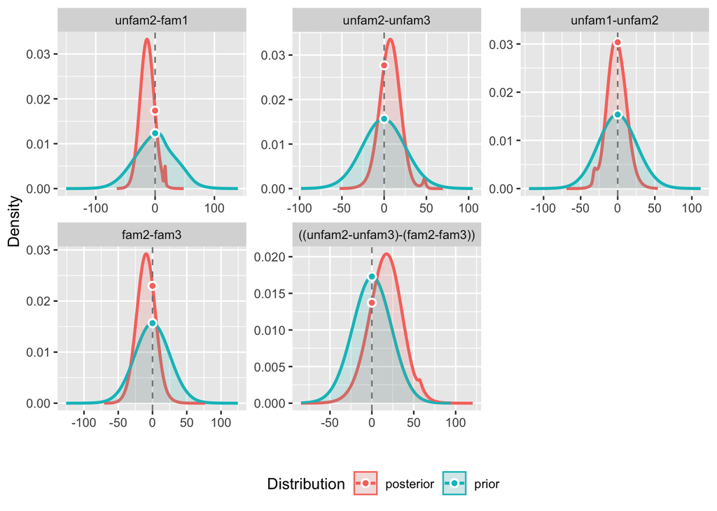

```r
plot(BF_m2)
```

Then I check the priors on these contrasts:

```r
point_estimate(m2_prior_pairs, centr = "mean", disp = TRUE)
```

```
## Point Estimate
##
## Parameter                     |     Mean |    SD
## ------------------------------------------------
## unfam2-fam1                   |    -0.04 | 33.69
## unfam2-unfam3                 |    -0.26 | 25.80
## unfam1-unfam2                 |    -0.17 | 26.13
## fam2-fam3                     |    -0.26 | 25.64
## ((unfam2-unfam3)-(fam2-fam3)) | 1.11e-03 | 23.19
```

Contrast 2,3 and 4 have similar priors. The first and last contrasts, however, have different priors. I think this is because for the first contrast we compare participants in two different Groups with two different TestSpeakers, whereas for contrast 2,3,4, only TestSpeaker differs and Group is the same. And for the last contrast, we look at a difference between two contrasts. My intuition is that it is completely fine that the priors on the contrasts differ, as long as I don’t start comparing contrasts with different priors. In other words, I can test ((unfam2-unfam3)-(fam2-fam3)) and ((unfam2-unfam3)-(unfam1-unfam2), but I can’t compare ((unfam2-unfam3)-(unfam2-fam1)) because these two contrasts have different priors.

For the factor sleepState, I also compute custom contrasts:

```r
MMR.emm2 = m2 %>%
  emmeans(~ sleepState)
```

```
## NOTE: Results may be misleading due to involvement in interactions
```

```r
MMR.emm2 # to set the custom contrast correctly
```

```
##  sleepState  emmean lower.HPD upper.HPD
##  awake        -3.95    -16.08      8.57
##  activesleep   8.89     -5.07     21.39
##  quietsleep    6.61     -8.93     20.95
##
## Results are averaged over the levels of: TestSpeaker, Group
## Point estimate displayed: median
## HPD interval probability: 0.95
```

```r
# set custom contrast sleep
custom_contrasts_sleep <- list(
  list("awake - activesleep and quietsleep" = c(1, -1/2, -1/2)),
  list("quietsleep - awake and activesleep" = c(-1/2, -1/2, 1)),
  list("quietsleep vs activesleep" =c(0, 1, -1))
)
```

I now compute the BF, but I don’t compare pairwise, but according to the contrast:

```r
#  comparison of prior distributions
# m2_prior <- unupdate(m2, verbose=FALSE) # sample priors from model
m2_prior_sleep <-
  m2_prior %>%
  emmeans(~ sleepState)
```

```
## NOTE: Results may be misleading due to involvement in interactions
```

```r
m2_prior_sleep = contrast(m2_prior_sleep, method = custom_contrasts_sleep)

#  comparison of posterior distributions
m2_post_sleep <-
  m2 %>%
  emmeans(~ sleepState)
```

```
## NOTE: Results may be misleading due to involvement in interactions
```

```r
m2_post_sleep = contrast(m2_post_sleep, method = custom_contrasts_sleep)

# Bayes Factors (Savage-Dickey density ratio)
BF_m2_sleep <-
  m2_post_sleep %>%
  bf_parameters(prior = m2_prior_sleep) %>%
  arrange(log_BF) # sort according to BF
BF_m2_sleep
```

```
## Bayes Factor (Savage-Dickey density ratio)
##
## Parameter                          |    BF
## ------------------------------------------
## quietsleep vs activesleep          | 0.404
## quietsleep - awake and activesleep | 0.482
## awake - activesleep and quietsleep |  1.19
##
## * Evidence Against The Null: 0
```

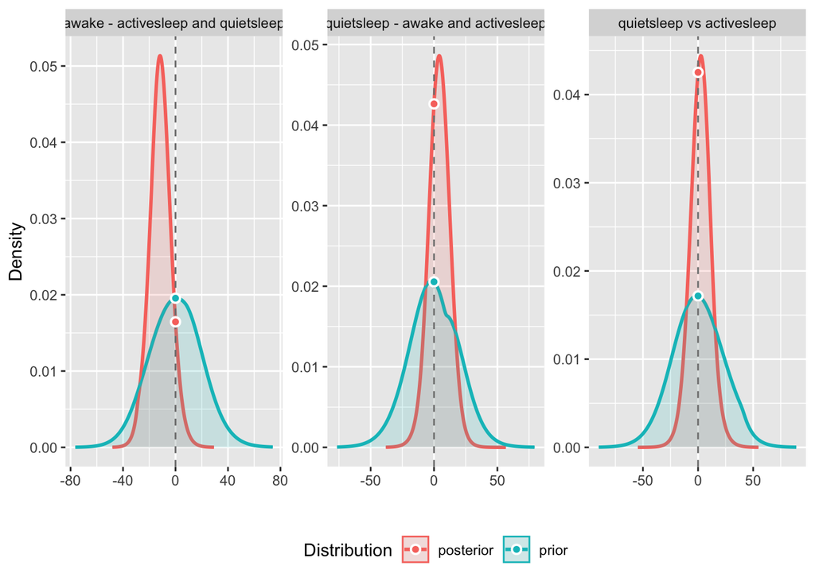

```r
plot(BF_m2_sleep)
```

Now I check the priors:

```r
point_estimate(m2_prior_sleep, centr = "mean", disp = TRUE)
```

```
## Point Estimate
##
## Parameter                          |  Mean |    SD
## --------------------------------------------------
## awake - activesleep and quietsleep |  0.01 | 19.94
## quietsleep - awake and activesleep | -0.06 | 19.79
## quietsleep vs activesleep          |  0.07 | 23.08
```

Same thing here as for the other comparisons: the priors are not the same, but I find that intuitive: for the first two contrasts, I combine two of the levels, whereas for the 3rd contrast, I only compare to separate levels.

I assume that I can compare contrasts 1 and 2, but I can’t compare contrast 1 and 3 or 2 and 3 (which would also make no sense in terms of hypotheses).

**In summary, my question: is it okay that the priors for different contrasts are different, if that is caused my the fact that for these contrasts I am comparing different combinations of levels of my factors, and as long as I don’t compare contrasts that have different priors? And if not, is there a way to force the priors to be the same for an entire custom contrast matrix?**

### Question 3

I have one additional question. In the output of emmeans(), I always get the warning: `NOTE: Results may be misleading due to involvement in interactions`. Is this a problem for the contrasts I am comparing?